encoding: UTF-8

# Question

los Juegos Olímpicos se realizan cada cuatro años y en estos participan países de mundial, alternando las sedes deportivas. La tabla muestra algunos datos de las últimas cinco versiones de los Juegos Olímpicos:

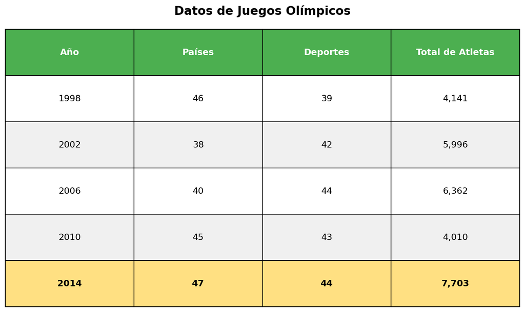

Del total de atletas participantes en 2014, el 5% compite en taekwondo. Para determinar el número de atletas detaekwondo ese año, se sugiere multiplicar 0.05 por el número de atletas que participaron en 2014. El procedimiento sugerido es:

## Answerlist

# Solution

Para resolver este problema, necesitamos evaluar si el procedimiento propuesto para calcular el número de atletas que compiten en taekwondo es matemáticamente correcto y suficiente.

### Análisis del procedimiento propuesto

**Datos disponibles:**

- Total de atletas en 2014: 7,703
- Porcentaje que compite en taekwondo: 5%
- Procedimiento sugerido: multiplicar 0.05 por 7,703

### Verificación matemática

El cálculo de un porcentaje de una cantidad total se realiza multiplicando el porcentaje (expresado como decimal) por la cantidad total:

**Cálculo:** 5% de 7,703 = 0.05 × 7,703 = 385

Por lo tanto, aproximadamente 385 atletas compitieron en taekwondo en 2014.

### Evaluación de cada opción

**Análisis de la respuesta correcta:**

El procedimiento es **suficiente** porque:

1. Tenemos el dato del total de atletas en 2014
2. Conocemos el porcentaje exacto que compite en taekwondo (5%)
3. La multiplicación 0.05 × 7,703 nos da directamente el número buscado
4. No se requiere información adicional para este cálculo

### Conclusión

El procedimiento sugerido (multiplicar 0.05 por el total de atletas) es matemáticamente correcto y contiene toda la información necesaria para determinar el número de atletas que compitieron en taekwondo en 2014.

## Answerlist

# Meta-information

exname: juegos_deportivos_interpretacion_representacion extype: schoice exsolution: 0001 exshuffle: TRUE exsection: Estadística|Análisis de datos|Porcentajes|Interpretación de tablas exextra[Type]: Interpretación y representación exextra[Level]: 2 exextra[Language]: es exextra[Course]: Matemáticas ICFES